# Capital BikeShare System Data Exploration Part I

## Introduction

This document explores a dataset containing times, stations, and races of over 150,000 bike records by race, from Washington DC Metro Area of February 2019.

## Preliminary Wrangling

### Gathering Data

```python
# import all packages and set plots to be embedded inline

import numpy as np
import pandas as pd
import matplotlib.pyplot as plt
import seaborn as sb

%matplotlib inline
```

```python
# reducing repetitive code

cat_markers = [['Member', 'o'],
               ['Casual', 's']]

def count_plot(df, string, up, order_counts) :
    sb.countplot(data = df, x = string, color = sb.color_palette()[0],  order = order_counts.index)
    locs, labels = plt.xticks()
    for loc, label in zip(locs, labels):
        count = order_counts[label.get_text()]
        string = '{}'.format(count)
        plt.text(loc, count+up, string, ha = 'center', color = 'black')
    plt.yticks([])
    plt.ylabel('Count')

def heat_plot(df, string_1, string_2) :
    plt.hist2d(data = df, x = string_1, y = string_2, cmin=0.5, cmap='viridis_r')
    plt.colorbar()
```

```python
# load in the dataset into a pandas dataframe
capital_bikeshare = pd.read_csv('201902-capitalbikeshare-tripdata.csv')
```

### Assessing Data

```python
# overview of informations
capital_bikeshare.info()
```

```
<class 'pandas.core.frame.DataFrame'>
RangeIndex: 158130 entries, 0 to 158129
Data columns (total 9 columns):
 #   Column                Non-Null Count   Dtype
---  ------                --------------   -----
 0   Duration              158130 non-null  int64
 1   Start date            158130 non-null  object
 2   End date              158130 non-null  object
 3   Start station number  158130 non-null  int64
 4   Start station         158130 non-null  object
 5   End station number    158130 non-null  int64
 6   End station           158130 non-null  object
 7   Bike number           158130 non-null  object
 8   Member type           158130 non-null  object
dtypes: int64(3), object(6)
memory usage: 10.9+ MB
```

```python
# descriptive statistics for duration
capital_bikeshare['Duration'].describe()
```

```
count    158130.000000
mean        895.846348
std        2279.471680
min          60.000000
25%         349.000000
50%         577.000000
75%         957.000000
max       86100.000000
Name: Duration, dtype: float64
```

```python
# high-level overview of data composition
capital_bikeshare.head(10)
```

|  | Duration | Start date | End date | Start station number | Start station | End station number | End station | Bike number | Member type |
| --- | --- | --- | --- | --- | --- | --- | --- | --- | --- |
| 0 | 206 | 2019-02-01 00:00:20 | 2019-02-01 00:03:47 | 31509 | New Jersey Ave & R St NW | 31636 | New Jersey Ave & N St NW/Dunbar HS | W21713 | Member |
| 1 | 297 | 2019-02-01 00:04:40 | 2019-02-01 00:09:38 | 31203 | 14th & Rhode Island Ave NW | 31519 | 1st & O St NW | E00013 | Member |
| 2 | 165 | 2019-02-01 00:06:34 | 2019-02-01 00:09:20 | 31303 | Tenleytown / Wisconsin Ave & Albemarle St NW | 31308 | 39th & Veazey St NW | W21703 | Member |
| 3 | 176 | 2019-02-01 00:06:49 | 2019-02-01 00:09:45 | 31400 | Georgia & New Hampshire Ave NW | 31401 | 14th St & Spring Rd NW | W21699 | Member |
| 4 | 105 | 2019-02-01 00:10:41 | 2019-02-01 00:12:27 | 31270 | 8th & D St NW | 31256 | 10th & E St NW | W21710 | Member |
| 5 | 757 | 2019-02-01 00:12:37 | 2019-02-01 00:25:14 | 31503 | Florida Ave & R St NW | 31126 | 11th & Girard St NW | W22157 | Member |
| 6 | 844 | 2019-02-01 00:16:59 | 2019-02-01 00:31:03 | 31324 | 18th & New Hampshire Ave NW | 31107 | Lamont & Mt Pleasant NW | W20543 | Member |
| 7 | 313 | 2019-02-01 00:19:08 | 2019-02-01 00:24:21 | 31241 | Thomas Circle | 31245 | 7th & R St NW / Shaw Library | W23906 | Member |
| 8 | 152 | 2019-02-01 00:22:31 | 2019-02-01 00:25:03 | 31020 | Wilson Blvd & Franklin Rd | 31030 | Lee Hwy & N Adams St | W21102 | Member |
| 9 | 1935 | 2019-02-01 00:28:43 | 2019-02-01 01:00:59 | 31104 | Adams Mill & Columbia Rd NW | 31108 | 4th & M St SW | W00946 | Member |

Quality issue :

- All columns must be renamed appropriatly.
- The values of columns *Start station number* and *End station number* are integers not strings.

Tidines issue :

- There should be a column for each bike race named *race_id*.

### Cleaning Data

Fortunately we have previously cleaned the `capital_bikeshare` dataset.

```python
# Loading cleaned pieces of data and viewing data composition
capital_bikeshare_clean = pd.read_csv('capital-bikeshare-clean.csv')
capital_bikeshare_clean.head(10)
```

|  | race_id | duration_sec | start_timestamp | end_timestamp | start_station_id | start_station_name | end_station_id | end_station_name | bike_id | biker_type |
| --- | --- | --- | --- | --- | --- | --- | --- | --- | --- | --- |
| 0 | 19001 | 206 | 2019-02-01 00:00:20 | 2019-02-01 00:03:47 | 31509 | New Jersey Ave & R St NW | 31636 | New Jersey Ave & N St NW/Dunbar HS | W21713 | Member |
| 1 | 19002 | 297 | 2019-02-01 00:04:40 | 2019-02-01 00:09:38 | 31203 | 14th & Rhode Island Ave NW | 31519 | 1st & O St NW | E00013 | Member |
| 2 | 19003 | 165 | 2019-02-01 00:06:34 | 2019-02-01 00:09:20 | 31303 | Tenleytown / Wisconsin Ave & Albemarle St NW | 31308 | 39th & Veazey St NW | W21703 | Member |
| 3 | 19004 | 176 | 2019-02-01 00:06:49 | 2019-02-01 00:09:45 | 31400 | Georgia & New Hampshire Ave NW | 31401 | 14th St & Spring Rd NW | W21699 | Member |
| 4 | 19005 | 105 | 2019-02-01 00:10:41 | 2019-02-01 00:12:27 | 31270 | 8th & D St NW | 31256 | 10th & E St NW | W21710 | Member |
| 5 | 19006 | 757 | 2019-02-01 00:12:37 | 2019-02-01 00:25:14 | 31503 | Florida Ave & R St NW | 31126 | 11th & Girard St NW | W22157 | Member |
| 6 | 19007 | 844 | 2019-02-01 00:16:59 | 2019-02-01 00:31:03 | 31324 | 18th & New Hampshire Ave NW | 31107 | Lamont & Mt Pleasant NW | W20543 | Member |
| 7 | 19008 | 313 | 2019-02-01 00:19:08 | 2019-02-01 00:24:21 | 31241 | Thomas Circle | 31245 | 7th & R St NW / Shaw Library | W23906 | Member |
| 8 | 19009 | 152 | 2019-02-01 00:22:31 | 2019-02-01 00:25:03 | 31020 | Wilson Blvd & Franklin Rd | 31030 | Lee Hwy & N Adams St | W21102 | Member |
| 9 | 19010 | 1935 | 2019-02-01 00:28:43 | 2019-02-01 01:00:59 | 31104 | Adams Mill & Columbia Rd NW | 31108 | 4th & M St SW | W00946 | Member |

#### Quality issue 2 :

IDs are better as strings, so we will redefine their type as object.

```python
# Modifying some types as object and testing them
capital_bikeshare_clean[['start_station_id', 'end_station_id', 'race_id']] = capital_bikeshare_clean[['start_station_id', 'end_station_id', 'race_id']].astype(object)
capital_bikeshare_clean.info()
```

```
<class 'pandas.core.frame.DataFrame'>
RangeIndex: 158130 entries, 0 to 158129
Data columns (total 10 columns):
 #   Column              Non-Null Count   Dtype
---  ------              --------------   -----
 0   race_id             158130 non-null  object
 1   duration_sec        158130 non-null  int64
 2   start_timestamp     158130 non-null  object
 3   end_timestamp       158130 non-null  object
 4   start_station_id    158130 non-null  object
 5   start_station_name  158130 non-null  object
 6   end_station_id      158130 non-null  object
 7   end_station_name    158130 non-null  object
 8   bike_id             158130 non-null  object
 9   biker_type          158130 non-null  object
dtypes: int64(1), object(9)
memory usage: 12.1+ MB
```

### What is the structure of your dataset ?

There are 158,130 bikes in the dataset with 10 features (race_id, duration_sec, start_timestamp, end_timestamp, start_station_id, start_station_name, end_station_id, end_station_name, bike_id and biker_type). Three variables are numerics and the others are categorical variables with the following types :

Quantitative variables :

- *duration_sec* : continious.
- *start_timestamp*, *end_timestamp* : discrete.

Qualitative variables :

- *race_id* : ordinal.
- *start_station_id*, *start_station_name*, *end_station_id*, *end_station_name*, *bike_id* and *biker_type* : nominal.

### What is/are the main feature(s) of interest in your dataset ?

I'm most interested in figuring out what features are better for predicting the best bike of the tournament.

### What features in the dataset do you think will help support your investigation into your feature(s) of interest ?

I expect that biker type will have the strongest effect on each bike's performance (best time) : the smaller the duration in each race. I also think that the number of races complited by a bike and the number of participants by race will have effects on its performance, though to a much smaller degree than the main effect of duration.

## Univariate Exploration

### Main Data :

**How are biker types distributed in the whole tournament ?**

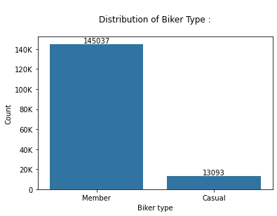

```python
# plotting count of biker types with count numbers

order_counts = capital_bikeshare_clean['biker_type'].value_counts()
count_plot(capital_bikeshare_clean, 'biker_type', 1300, order_counts)
plt.yticks([0, 2e4, 4e4, 6e4, 8e4, 1e5, 1.2e5, 1.4e5], [0, '20K', '40K', '60K', '80K', '100K', '120K', '140K'])
plt.ylabel('Count')
plt.xlabel('Biker type')
plt.title('\nDistribution of Biker Type :\n');
```

*biker_type* has two values whose Member is majority, going up to 145,037 and Casual is minority with 13,093.

**How are durations distributed in the whole tournament ?**

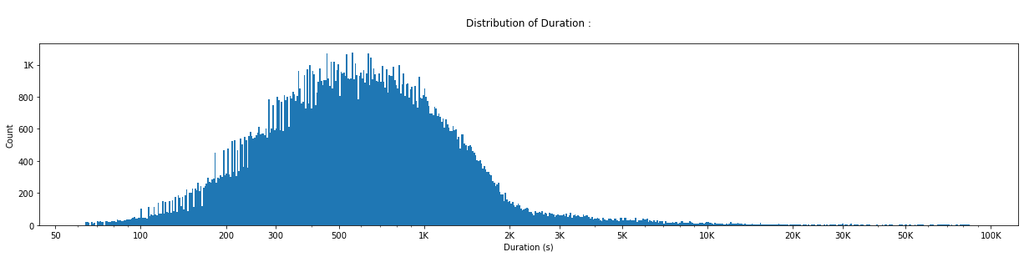

```python
# plotting count of durations in the whole tournament, with a log scale

bins = 10 ** np.arange(1.8, np.log10(capital_bikeshare_clean['duration_sec'].max())+0.005, 0.005)

plt.figure(figsize=[21, 4])
plt.hist(data = capital_bikeshare_clean, x = 'duration_sec', bins = bins)
plt.xscale('log')
plt.xticks([50, 100, 200, 300, 500, 1e3, 2e3, 3e3, 5e3, 1e4, 2e4, 3e4, 5e4, 1e5], [50, 100, 200, 300, 500, '1K', '2K', '3K', '5K', '10K', '20K', '30K', '50K', '100K'])
plt.yticks([0, 200, 400, 600, 800, 1e3], [0, 200, 400, 600, 800, '1K'])
plt.xlabel('Duration (s)')
plt.ylabel('Count')
plt.title('\nDistribution of Duration :\n');
```

*duration_sec* has a long-tail distribution, with many short-time bikers and few long-time bikers. When plotted on a logarithmic scale, this distribution appears roughly unimodal, with a peak between 350 and 1,000.

**How are races distributed in the whole tournament ?**

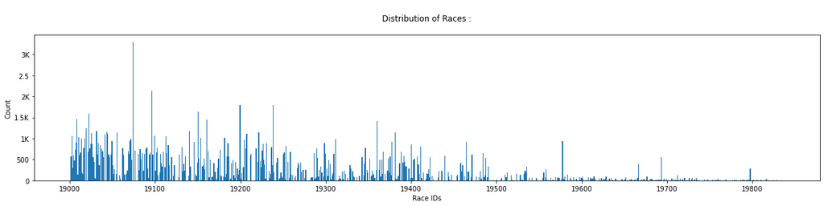

```python
# plotting races count in decreasing order

order_counts = capital_bikeshare_clean['race_id'].value_counts()

bins = np.arange(19000, capital_bikeshare_clean['race_id'].max()+1, 1)

plt.figure(figsize=[21, 4])
plt.hist(data = capital_bikeshare_clean, x = 'race_id', bins = bins)
plt.xlabel('Race IDs')
plt.ylabel('Count')
plt.xticks([19000, 19100, 19200, 19300, 19400, 19500, 19600, 19700, 19800])
plt.yticks([0, 5e2, 1e3, 1.5e3, 2e3, 2.5e3, 3e3], [0, 500, '1K', '1.5K', '2K', '2.5', '3K'])
plt.title('\nDistribution of Races :\n');
```

> **Note :** The races have been identified in order of date and time of recording the first bike to go. So they are classified in order, beginning with the prefix 19.

Now we have a problem about the races : the original data frame is a set of records of each bike at each race in starting order in the whole tournament. What about the race number of each bike ? And the number of bikes at each race ? To answer his questions we will load and explore two datasets named `capital_bike` and `capital_race` extracted from `capital_bikeshare_clean` dataset.

### Extracted Data 1 :

```python
# Loading bike pieces of data and viewing its composition
capital_bike = pd.read_csv('capital-bike.csv')
capital_bike.head(10)
```

|  | bike_id | biker_type | duration_sum | race_count |
| --- | --- | --- | --- | --- |
| 0 | W21713 | Member | 8446 | 41 |
| 1 | E00013 | Member | 61182 | 206 |
| 2 | W21703 | Member | 11055 | 67 |
| 3 | W21699 | Member | 5104 | 29 |
| 4 | W21710 | Member | 3990 | 38 |
| 5 | W22157 | Member | 30280 | 40 |
| 6 | W20543 | Member | 16036 | 19 |
| 7 | W23906 | Member | 4069 | 13 |
| 8 | W21102 | Member | 13376 | 88 |
| 9 | W00946 | Member | 73530 | 38 |

**How are biker types distributed in the bikes set ?**

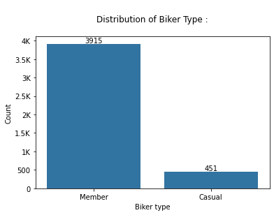

```python
# plotting count of biker types with count numbers

order_counts = capital_bike['biker_type'].value_counts()
count_plot(capital_bike, 'biker_type', 38, order_counts)
plt.yticks([0, 500, 1e3, 1.5e3, 2e3, 2.5e3, 3e3, 3.5e3, 4e3], [0, 500, '1K', '1.5K', '2K', '2.5K', '3K', '3.5K', '4K'])
plt.ylabel('Count')
plt.xlabel('Biker type')
plt.title('\nDistribution of Biker Type :\n');
```

In this dataset, *biker_type* also has two variables whose Member is majority with 3,915 and Casual is minority with 451.

**How are races counts distributed in the bikes set ?**

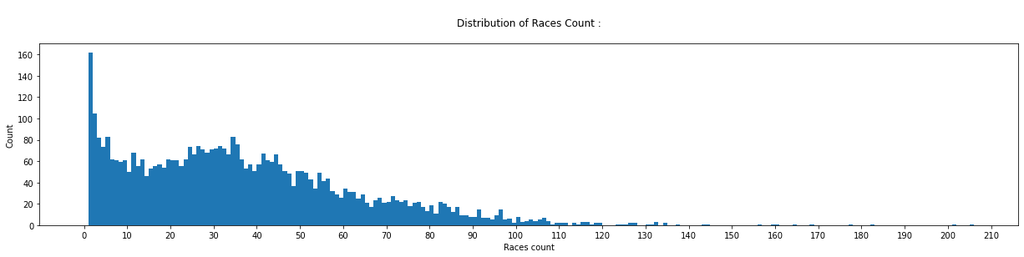

```python
# plotting count of races participation in the whole tournament

order_counts = capital_bike['race_count'].value_counts()

bins = np.arange(0, capital_bike['race_count'].max()+1, 1)

plt.figure(figsize=[21, 4])
plt.hist(data = capital_bike, x = 'race_count', bins = bins)
plt.xticks([0, 10, 20, 30, 40, 50, 60, 70, 80, 90, 100, 110, 120, 130, 140, 150, 160, 170, 180, 190, 200, 210])
plt.xlabel('Races count')
plt.ylabel('Count')
plt.title('\nDistribution of Races Count :\n');
```

**How are duration sums distributed in the bikes set ?**

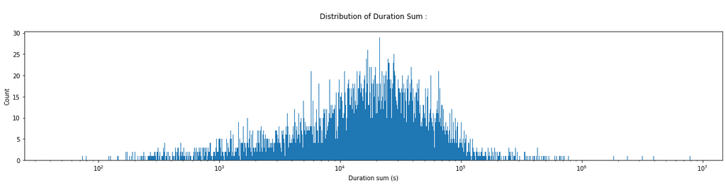

```python
# plotting count of duration sums of each bike with log scale

bins = 10 ** np.arange(1.651, np.log10(capital_bike['duration_sum'].max())+0.005, 0.005)

plt.figure(figsize=[21, 4])
plt.hist(data = capital_bike, x = 'duration_sum', bins = bins)
plt.xscale('log')
plt.xlabel('Duration sum (s)')
plt.ylabel('Count')
plt.title('\nDistribution of Duration Sum :\n');
```

### Extracted Data 2 :

```python
# loading race pieces of data and viewing its composition
capital_race = pd.read_csv('capital-race.csv')
capital_race.head(10)
```

|  | race_id | winner_time | winner_id | winner_type | participants |
| --- | --- | --- | --- | --- | --- |
| 0 | 19001 | 61 | W21898 | Member | 576 |
| 1 | 19002 | 61 | W00388 | Member | 1056 |
| 2 | 19003 | 93 | W20546 | Member | 304 |
| 3 | 19004 | 109 | W22337 | Member | 605 |
| 4 | 19005 | 93 | W23142 | Member | 473 |
| 5 | 19006 | 60 | W20627 | Member | 724 |
| 6 | 19007 | 61 | W23764 | Member | 899 |
| 7 | 19008 | 60 | W21666 | Member | 1463 |
| 8 | 19009 | 95 | W20614 | Member | 135 |
| 9 | 19010 | 70 | W23874 | Member | 1032 |

**How are winners types distributed in the races set ?**

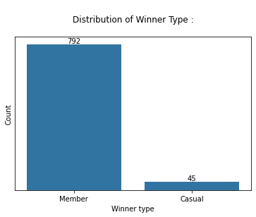

```python
# plotting count of biker types with count numbers

order_counts = capital_race['winner_type'].value_counts()
count_plot(capital_race, 'winner_type', 6, order_counts)
plt.xlabel('Winner type')
plt.ylabel('Count')
plt.title('\nDistribution of Winner Type :\n');
```

**How are winners times distributed in the races set ?**

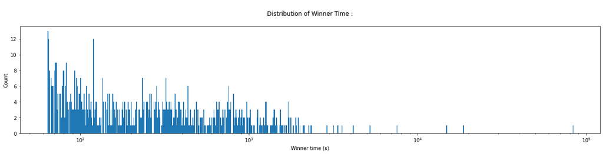

```python
# plotting count of winner times with log scale

bins = 10 ** np.arange(1.8, np.log10(capital_race['winner_time'].max())+0.005, 0.005)

plt.figure(figsize=[21, 4])
plt.hist(data = capital_race, x = 'winner_time', bins = bins)
plt.xscale('log')
plt.xlabel('Winner time (s)')
plt.ylabel('Count')
plt.title('\nDistribution of Winner Time :\n');
```

**How are participants distributed in the races set ?**

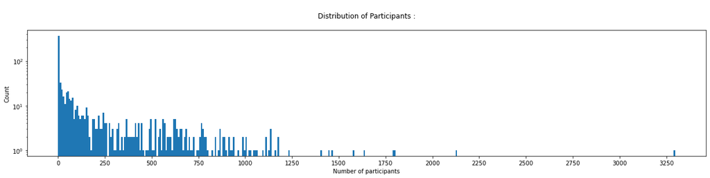

```python
# plotting count of number of participants in the whole tournament, with a log scale

bins = np.arange(0, capital_race['participants'].max()+8.2, 8.2)

plt.figure(figsize=[21, 4])
plt.hist(data = capital_race, x = 'participants', bins = bins)
plt.xticks([0, 250, 500, 750, 1000, 1250, 1500, 1750, 2000, 2250, 2500, 2750, 3000, 3250])
plt.xlabel('Number of participants')
plt.yscale('log')
plt.ylabel('Count')
plt.title('\nDistribution of Participants :\n');
```

We plotted the count of the distribution on a logarithmic scale, so *participants* long-tail showed up. There are with many alone bikers, some medium groups of bikers and few bigger groups of bikers.

### Discuss the distribution(s) of your variable(s) of interest. Were there any unusual points ? Did you need to perform any transformations ?

Time variables (*duration_sec*, *duration_sum* and *winner_time*) took on large ranges of values, so we looked at the data using a log transform. Under the transformation, the data looked unimodal, with one peak per variable.

### Of the features you investigated, were there any unusual distributions ? Did you perform any operations on the data to tidy, adjust, or change the form of the data ? If so, why did you do this ?

When investigating the *race_id* variable, a number of question showed up about the completness of data. We needed the race number of each bike and the number of bikes at each race. So we loaded and explored the two datasets `capital_bike` and `capital_race` previously extracted from `capital_bikeshare_clean` dataset.

## Bivariate Exploration

### Main Data :

**How is duration distributed by biker type in the whole tournament ?**

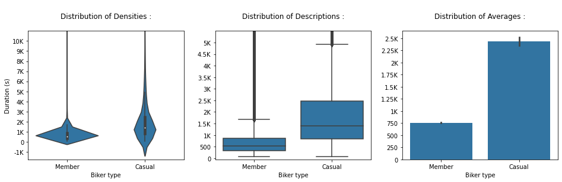

```python
# plotting three descriptions of duration for biker types

plt.figure(figsize = [16, 4])

plt.subplot(1, 3, 1)
sb.violinplot(data = capital_bikeshare_clean, x = 'biker_type', y = 'duration_sec', color = sb.color_palette()[0])
plt.xlabel('Biker type')
plt.ylabel('Duration (s)')
plt.ylim([-1750, 11000])
plt.yticks([-1e3, 0, 1e3,  2e3, 3e3, 4e3, 5e3, 6e3, 7e3, 8e3, 9e3, 1e4], ['-1K', 0, '1K', '2K', '3K', '4K', '5K', '6K', '7K', '8K', '9K', '10K'])
plt.title('\nDistribution of Densities :\n')

plt.subplot(1, 3, 2)
sb.boxplot(data = capital_bikeshare_clean, x = 'biker_type', y = 'duration_sec', color = sb.color_palette()[0])
plt.xlabel('Biker type')
plt.ylabel('')
plt.ylim([-50, 5500])
plt.yticks([0, 500, 1000, 1500, 2000, 2500, 3000, 3500, 4000, 4500, 5000], [0, 500, '1K', '1.5K', '2K', '2.5K', '3K', '3.5K', '4K', '4.5K', '5K'])
plt.title('\nDistribution of Descriptions :\n')

plt.subplot(1, 3, 3)
sb.barplot(data = capital_bikeshare_clean, x = 'biker_type', y = 'duration_sec', color = sb.color_palette()[0])
plt.xlabel('Biker type')
plt.ylabel('')
plt.yticks([0, 250, 500, 750, 1000, 1250, 1500, 1750, 2000, 2250, 2500], [0, 250, 500, 750, '1K', '1.25K', '1.5K', '1.75K', '2K', '2.25K', '2.5K'])
plt.title('\nDistribution of Averages :\n');
```

There we used three plots to view differents values in *biker_type* variable, with the two maxs going over 80,000. In the violinplot, we can see that the Member biker type is larger than the Casual biker type. The boxplot show the values of the description (max, std, 75%, 50%, 25% and min). And there is averages of those two values in the barplot.

**How are races distributed by biker type in the whole tournament ?**

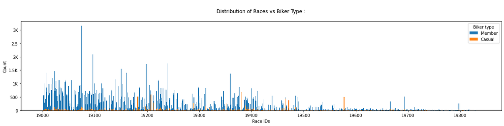

```python
# plotting races count of each biker type

order_counts = capital_bikeshare_clean['race_id'].value_counts()

bins = np.arange(19000, capital_bikeshare_clean['race_id'].max()+1, 1)

plt.figure(figsize = [21, 4])
for cat, marker in cat_markers :
    df_cat = capital_bikeshare_clean.query('biker_type == "{}"'.format(cat))
    plt.hist(data = df_cat, x = 'race_id', bins = bins)
plt.xlabel('Race IDs')
plt.ylabel('Count')
plt.xticks([19000, 19100, 19200, 19300, 19400, 19500, 19600, 19700, 19800])
plt.yticks([0, 5e2, 1e3, 1.5e3, 2e3, 2.5e3, 3e3], [0, 500, '1K', '1.5K', '2K', '2.5', '3K'])
plt.legend(['Member', 'Casual'], title = 'Biker type')
plt.title('\nDistribution of Races vs Biker Type :\n');
```

**How are durations distributed by race in the whole tournament ?**

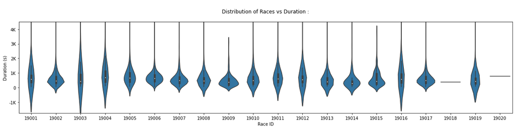

```python
# plotting the first twenty races with violinplot

plt.figure(figsize = [21, 4])
sb.violinplot(data = capital_bikeshare_clean.query('race_id <= 19020'), x = 'race_id', y = 'duration_sec', color = sb.color_palette()[0])
plt.ylim([-1750, 4500])
plt.yticks([-1000, 0, 1000,  2000, 3000, 4000], ['-1K', 0, '1K', '2K', '3K', '4K']);
plt.xlabel('Race ID')
plt.ylabel('Duration (s)')
plt.title('\nDistribution of Races vs Duration :\n');
```

The *race_id* distribution is too large, so we just plotted the first twenty races. There we used violin plots to view differents values of durations densities, with the max going over 80,000.

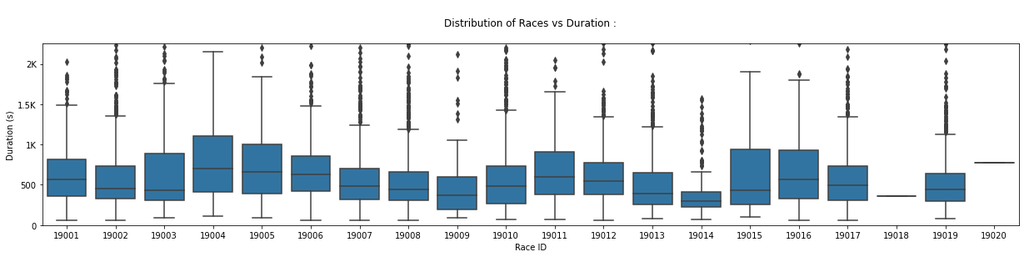

```python
# plotting the first twenty races with boxplot

plt.figure(figsize = [21, 4])
sb.boxplot(data = capital_bikeshare_clean.query('race_id <= 19020'), x = 'race_id', y = 'duration_sec', color = sb.color_palette()[0])
plt.ylim([0, 2250])
plt.yticks([0, 500, 1000, 1500, 2000], [0, 500, '1K', '1.5K', '2K'])
plt.xlabel('Race ID')
plt.ylabel('Duration (s)')
plt.title('\nDistribution of Races vs Duration :\n');
```

The *race_id* distribution is too large, so we just plotted the first twenty races. There, we used box plots to view differents values of durations description with the maxs going over 80,000.

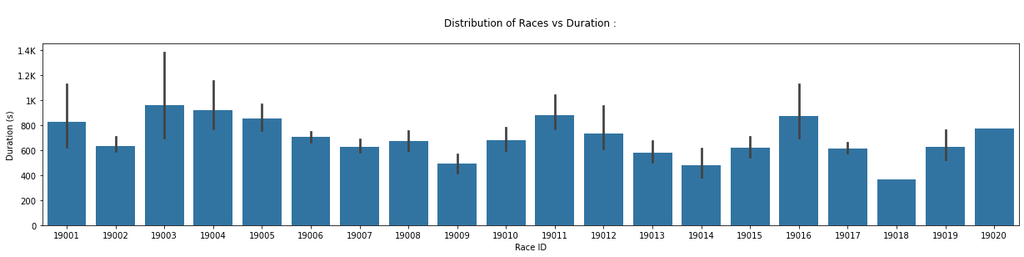

```python
# plotting the first twenty races with barplot

plt.figure(figsize = [21, 4])
sb.barplot(data = capital_bikeshare_clean.query('race_id <= 19020'), x = 'race_id', y = 'duration_sec', color = sb.color_palette()[0])
plt.yticks([0, 200, 400, 600, 800, 1000, 1200, 1400], [0, 200, 400, 600, 800, '1K', '1.2K', '1.4K'])
plt.xlabel('Race ID')
plt.ylabel('Duration (s)')
plt.title('\nDistribution of Races vs Duration :\n');
```

The *race_id* distribution is too large, so we just plotted the first twenty races. There, we used bar plots to view differents values of durations averages.

### Extracted Data 1 :

**What is the correlation between races counts and durations sums in the bikes set ?**

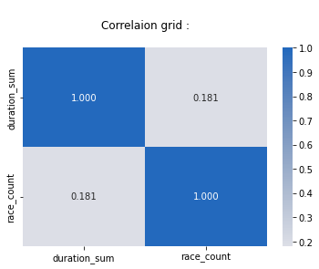

```python
# plotting correlations grid

sb.heatmap(capital_bike[['duration_sum', 'race_count']].corr(), annot = True, fmt = '.3f', cmap = 'vlag_r', center = 0)
plt.title('\nCorrelaion grid :\n');
```

As expected, the *duration_sum* and *race_count* variables have a positive correlation.

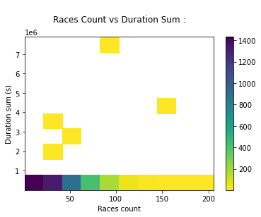

```python
# plotting race count vs duration sum

heat_plot(capital_bike, 'race_count', 'duration_sum')
plt.xlabel('Races count')
plt.ylabel('Duration sum (s)')
plt.title('\nRaces Count vs Duration Sum :\n');
```

In this distribution we can see the relationship of variables, *race_count* against *duration_sum*. As plotted in the HeatMap, the correlation is 0.181 so there is an interdependence.

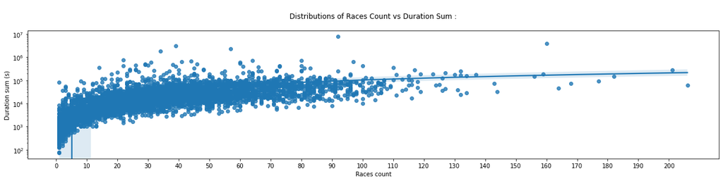

```python
# plotting race count vs duration sum, with a log scale

plt.figure(figsize = [21, 4])
sb.regplot(data = capital_bike, x = 'race_count', y = 'duration_sum')
plt.xticks([0, 10, 20, 30, 40, 50, 60, 70, 80, 90, 100, 110, 120, 130, 140, 150, 160, 170, 180, 190, 200])
plt.xlabel('Races count')
plt.ylabel('Duration sum (s)')
plt.yscale('log')
plt.title('\nDistributions of Races Count vs Duration Sum :\n');
```

The *duration_sum* variable is plotted in a logarithmic scale so the distristribution looks logarithmic too.

**How are durations sums distributed by biker type in the bikes set ?**

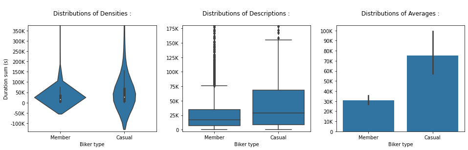

```python
# plotting three descriptions of duration sums for biker types

plt.figure(figsize = [16, 4])

plt.subplot(1, 3, 1)
sb.violinplot(data = capital_bike, x = 'biker_type', y = 'duration_sum', color = sb.color_palette()[0])
plt.xlabel('Biker type')
plt.ylabel('Duration sum (s)')
plt.ylim([-1.4e5, 3.75e5])
plt.yticks([-1e5, -5e4, 0, 5e4, 1e5, 1.5e5, 2e5, 2.5e5, 3e5, 3.5e5], ['-100K', '-50K', 0, '50K', '100K', '150K', '200K', '250K', '300K', '350K'])
plt.title('\nDistributions of Densities :\n')

plt.subplot(1, 3, 2)
sb.boxplot(data = capital_bike, x = 'biker_type', y = 'duration_sum', color = sb.color_palette()[0])
plt.xlabel('Biker type')
plt.ylabel('')
plt.ylim([-3e3, 1.8e5])
plt.yticks([0, 2.5e4, 5e4, 7.5e4, 1e5, 1.25e5, 1.5e5, 1.75e5], [0, '25K', '50K', '75K', '100K', '125K', '150K', '175K'])
plt.title('\nDistributions of Descriptions :\n')

plt.subplot(1, 3, 3)
sb.barplot(data = capital_bike, x = 'biker_type', y = 'duration_sum', color = sb.color_palette()[0])
plt.xlabel('Biker type');
plt.ylabel('')
plt.ylim([0, 105000])
plt.yticks([0, 1e4, 2e4, 3e4, 4e4, 5e4, 6e4, 7e4, 8e4, 9e4, 1e5], [0, '10K', '20K', '30K', '40K', '50K', '60K', '70K', '80K', '90K', '100K'])
plt.title('\nDistributions of Averages :\n');
```

There is views of differents values of *duration_sum* variable, with the Member max going over 7,750,000 and the Casual max over 3,000,000. In the violinplot, we can see that the Member biker type is larger than the Casual biker type. The boxplot show the values of the description (max, std, 75%, 50%, 25% and min). And there is averages of those two values in the barplot.

**How are races counts distributed by biker type in the bikes set ?**

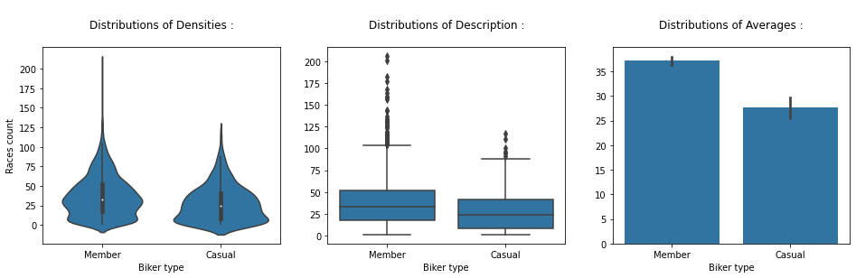

```python
# plotting three descriptions of race count for biker types

plt.figure(figsize = [16, 4])

plt.subplot(1, 3, 1)
sb.violinplot(data = capital_bike, x = 'biker_type', y = 'race_count', color = sb.color_palette()[0])
plt.xlabel('Biker type')
plt.ylabel('Races count')
plt.yticks([0, 25, 50, 75, 100, 125, 150, 175, 200])
plt.title('\nDistributions of Densities :\n')

plt.subplot(1, 3, 2)
sb.boxplot(data = capital_bike, x = 'biker_type', y = 'race_count', color = sb.color_palette()[0])
plt.xlabel('Biker type')
plt.ylabel('')
plt.yticks([0, 25, 50, 75, 100, 125, 150, 175, 200])
plt.title('\nDistributions of Description :\n')

plt.subplot(1, 3, 3)
sb.barplot(data = capital_bike, x = 'biker_type', y = 'race_count', color = sb.color_palette()[0])
plt.xlabel('Biker type')
plt.ylabel('')
plt.title('\nDistributions of Averages :\n');
```

One more time, we used three plots to view differents values in *race_count* variable, with the Member max going to 206 and the Casual max to 117. In the violinplot, we can see that the Member biker type is greater than the Casual biker type. The boxplot show the values of the description (max, std, 75%, 50%, 25% and min). And there is averages of those two values in the barplot.

### Extracted Data 2 :

**What are the correlations between winners times, participants and races in the races set ?**

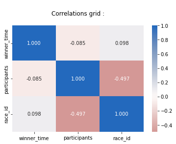

```python
# plotting correlation grid

sb.heatmap(capital_race[['winner_time', 'participants', 'race_id']].corr(), annot = True, fmt = '.3f', cmap = 'vlag_r', center = 0)
plt.title('\nCorrelations grid :\n');
```

As plotted here, we have one positive correlation and two negative correlations.

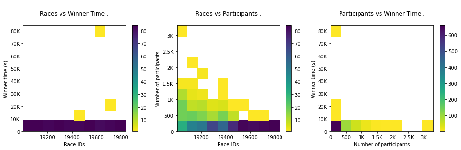

```python
# plotting the three versus : rases vs winner times vs participants

plt.figure(figsize = [16, 4])

plt.subplot(1, 3, 1)
heat_plot(capital_race, 'race_id', 'winner_time')
plt.yticks([0, 1e4, 2e4, 3e4, 4e4, 5e4, 6e4, 7e4, 8e4], [0, '10K', '20K', '30K', '40K', '50K', '60K', '70K', '80K'])
plt.xlabel('Race IDs')
plt.ylabel('Winner time (s)')
plt.title('\nRaces vs Winner Time :\n')

plt.subplot(1, 3, 2)
heat_plot(capital_race, 'race_id', 'participants')
plt.yticks([0, 500, 1000, 1500, 2000, 2500, 3000],  [0, 500, '1K', '1.5K', '2K', '2.5K', '3K'])
plt.xlabel('Race IDs')
plt.ylabel('Number of participants')
plt.title('\nRaces vs Participants :\n')

plt.subplot(1, 3, 3)
heat_plot(capital_race, 'participants',  'winner_time')
plt.yticks([0, 1e4, 2e4, 3e4, 4e4, 5e4, 6e4, 7e4, 8e4], [0, '10K', '20K', '30K', '40K', '50K', '60K', '70K', '80K'])
plt.ylabel('Winner time (s)')
plt.xticks([0, 500, 1000, 1500, 2000, 2500, 3000],  [0, 500, '1K', '1.5K', '2K', '2.5K', '3K'])
plt.xlabel('Number of participants')
plt.title('\nParticipants vs Winner Time :\n');
```

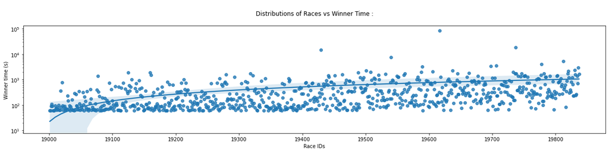

```python
# plotting races vs winner time, with a log scale

plt.figure(figsize = [21, 4])
sb.regplot(data = capital_race, x = 'race_id', y = 'winner_time')
plt.xticks([19000, 19100, 19200, 19300, 19400, 19500, 19600, 19700, 19800])
plt.yscale('log')
plt.ylabel('Winner time (s)')
plt.xlabel('Race IDs')
plt.title('\nDistributions of Races vs Winner Time :\n');
```

The *winner_time* variable is plotted in a logarithmic scale to show the linearity of the distristribution.

**How are winners times distributed by winner type in the races set ?**

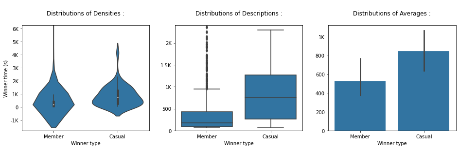

```python
# plotting three descriptions of winner time for biker types

plt.figure(figsize = [16, 4])

plt.subplot(1, 3, 1)
sb.violinplot(data = capital_race, x = 'winner_type', y = 'winner_time', color = sb.color_palette()[0])
plt.xlabel('Winner type')
plt.ylabel('Winner time (s)')
plt.ylim([-1800, 6250])
plt.yticks([-1e3, 0, 1e3, 2e3, 3e3, 4e3, 5e3, 6e3], ['-1K', 0, '1K', '2K', '3K', '4K', '5K', '6K'])
plt.title('\nDistributions of Densities :\n')

plt.subplot(1, 3, 2)
sb.boxplot(data = capital_race, x = 'winner_type', y = 'winner_time', color = sb.color_palette()[0])
plt.xlabel('Winner type')
plt.ylabel('')
plt.ylim([0, 2400])
plt.yticks([0, 500, 1e3, 15e2, 2e3], [0, 500, '1K', '1.5K', '2K'])
plt.title('\nDistributions of Descriptions :\n')

plt.subplot(1, 3, 3)
sb.barplot(data = capital_race, x = 'winner_type', y = 'winner_time', color = sb.color_palette()[0])
plt.xlabel('Winner type')
plt.ylabel('')
plt.yticks([0, 2e2, 4e2, 6e2, 8e2, 1e3], [0, 200, 400, 600, 800, '1K'])
plt.title('\nDistributions of Averages :\n');
```

**How are participants distributed by winner type in the races set ?**

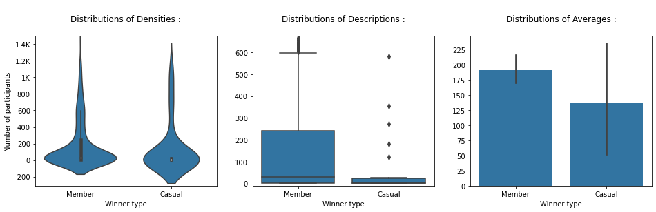

```python
# plotting three descriptions of participants for biker types

plt.figure(figsize = [16, 4])

plt.subplot(1, 3, 1)
sb.violinplot(data = capital_race, x = 'winner_type', y = 'participants', color = sb.color_palette()[0])
plt.xlabel('Winner type')
plt.ylabel('Number of participants')
plt.ylim([-310, 1500])
plt.yticks([-2e2, 0, 2e2, 4e2, 6e2, 8e2, 1e3, 12e2, 14e2], [-200, 0, 200, 400, 600, 800, '1K', '1.2K', '1.4K'])
plt.title('\nDistributions of Densities :\n')

plt.subplot(1, 3, 2)
sb.boxplot(data = capital_race, x = 'winner_type', y = 'participants', color = sb.color_palette()[0])
plt.xlabel('Winner type')
plt.ylabel('')
plt.ylim([-10, 675])
plt.title('\nDistributions of Descriptions :\n')

plt.subplot(1, 3, 3)
sb.barplot(data = capital_race, x = 'winner_type', y = 'participants', color = sb.color_palette()[0])
plt.xlabel('Winner type')
plt.ylabel('')
plt.yticks([0, 25, 50, 75, 100, 125, 150, 175, 200, 225])
plt.title('\nDistributions of Averages :\n');
```

### Talk about some of the relationships you observed in this part of the investigation. How did the feature(s) of interest vary with other features in the dataset ?

Time variables (*duration_sec*, *duration_sum* and *winner_time*) had an expected positive correlation with the races variables (*race_id* and *race_count*), even before transforming the features. An approximately linear relationship was observed when time was plotted on a log scale. We observed this two things :

- the Member biker type have the best race times ;
- the Member biker type have completed way more races.

Moreover, the number of races is proportional to the sum of the race times and this increase as races follow each other.

### Did you observe any interesting relationships between the other features (not the main feature(s) of interest) ?

Two relationships were found in the association between the *participants* variable and the two previous ones. Two negative correlations was observed so we haven't explored them further. There was also a small interaction with type variables (*biker_type* and *winner_type*). We just observed that the Member biker type is more numerous.

## Multivariate Exploration

### Main Data :

**How are durations distributed by races for each biker type in the whole tournament ?**

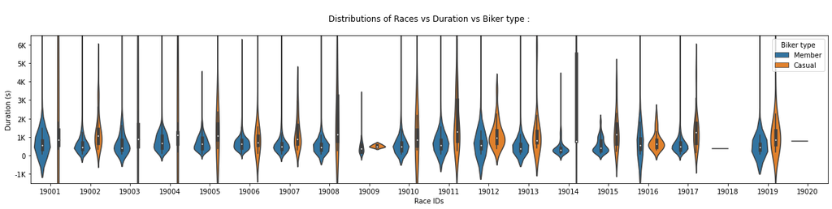

```python
# plotting the first twenty races with violinplots

plt.figure(figsize = [21, 4])
sb.violinplot(data = capital_bikeshare_clean.query('race_id <= 19020'), x = 'race_id', y = 'duration_sec', hue = 'biker_type')
plt.ylim([-1500, 6500])
plt.yticks([-1000, 0, 1000,  2000, 3000, 4000, 5000, 6000], ['-1K', 0, '1K', '2K', '3K', '4K', '5K', '6K'])
plt.ylabel('Duration (s)')
plt.xlabel('Race IDs')
plt.legend(loc = 1, title = 'Biker type')
plt.title('\nDistributions of Races vs Duration vs Biker type :\n');
```

The *race_id* distribution is too large, so we just plotted the first twenty races. We can view differents values of *duration_sec* variable, with values of the *biker_type* variable. So this violin plots show that the Casual biker type is greater than the Member biker type.

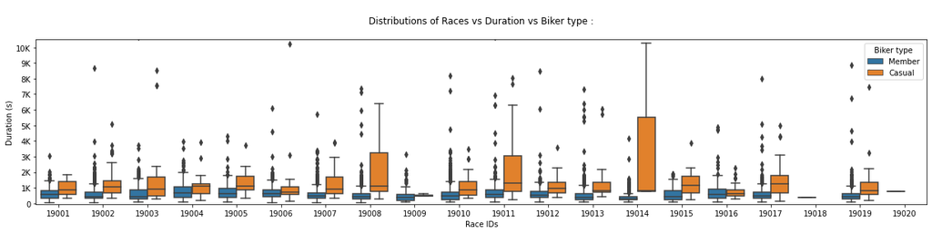

```python
# plotting the first twenty races with boxplots

plt.figure(figsize = [21, 4])
sb.boxplot(data = capital_bikeshare_clean.query('race_id <= 19020'), x = 'race_id', y = 'duration_sec', hue = 'biker_type')
plt.ylim([-50, 10500])
plt.yticks([0, 1000,  2000, 3000, 4000, 5000, 6000, 7000, 8000, 9000, 10000], [0, '1K', '2K', '3K', '4K', '5K', '6K', '7K', '8K', '9K', '10K'])
plt.ylabel('Duration (s)')
plt.xlabel('Race IDs')
plt.legend(loc = 1, title = 'Biker type')
plt.title('\nDistributions of Races vs Duration vs Biker type :\n');
```

There, we can view differents values of *duration_sec* variable, with values of the *biker_type* variable. This boxplot show the values of the description (max, std, 75%, 50%, 25% and min).

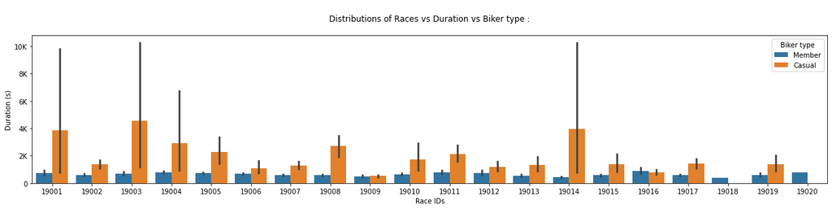

```python
# plotting the first twenty races with barplots

plt.figure(figsize = [21, 4])
sb.barplot(data = capital_bikeshare_clean.query('race_id <= 19020'), x = 'race_id', y = 'duration_sec', hue = 'biker_type')
plt.yticks([0, 2e3, 4e3, 6e3, 8e3, 10e3], [0, '2K', '4K', '6K', '8K', '10K'])
plt.ylabel('Duration (s)')
plt.xlabel('Race IDs')
plt.legend(loc = 1, title = 'Biker type')
plt.title('\nDistributions of Races vs Duration vs Biker type :\n');
```

Then we can view differents values of *duration_sec* variable, with values of the *biker_type* variable. In this bar plots, there are averages of those two Bikers types.

### Extracted Data 1 :

**What is the relationship between races counts, durations sums and biker types in the bikes set ?**

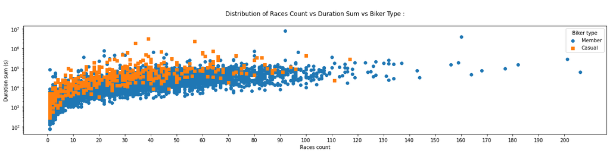

```python
# plotting race counts vs duration sums vs biker types

plt.figure(figsize = [21, 4])
for cat, marker in cat_markers :
    df_cat = capital_bike.query('biker_type == "{}"'.format(cat))
    plt.scatter(data = df_cat, x = 'race_count', y = 'duration_sum', marker = marker)
plt.xticks([0, 10, 20, 30, 40, 50, 60, 70, 80, 90, 100, 110, 120, 130, 140, 150, 160, 170, 180, 190, 200])
plt.xlabel('Races count')
plt.ylabel('Duration sum (s)')
plt.yscale('log')
plt.legend(['Member', 'Casual'], title = 'Biker type')
plt.title('\nDistribution of Races Count vs Duration Sum vs Biker Type :\n');
```

Plotted in a logarithmic scale, we can see the *duration_sum* variable depending on the *race_count* one. It look such logarithmic so, this distribution is linear in a normal scale.

### Extracted Data 2 :

**What is the relationship between races, winners times and participants ?**

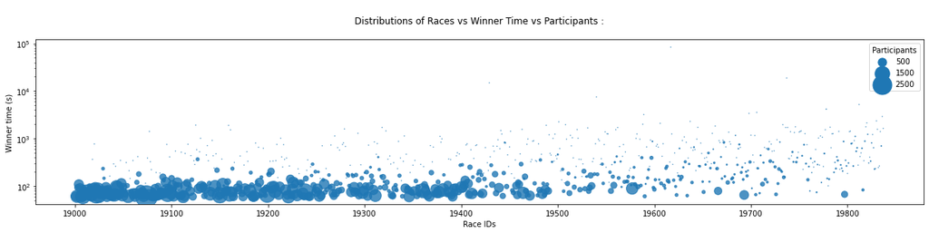

```python
# plotting races vs winner times vs participants

plt.figure(figsize = [21, 4])
sb.regplot(data = capital_race, x = 'race_id', y = 'winner_time', x_jitter = 0.01, fit_reg = False, scatter_kws = {'s' : capital_race['participants']/4});
plt.yscale('log')
plt.ylabel('Winner time (s)')
plt.xlabel('Race IDs')
plt.xticks([19000, 19100, 19200, 19300, 19400, 19500, 19600, 19700, 19800])
plt.title('\nDistributions of Races vs Winner Time vs Participants :\n')

sizes = [500, 1500, 2500]
legend_obj = []
for s in sizes:
    legend_obj.append(plt.scatter([], [], s = s/4, color = sb.color_palette()[0]))
plt.legend(legend_obj, sizes, title = 'Participants');
```

The scatterplot have a logarithmin scale on y-axis, so the linear distribution of *race_id* and *winner_time* variables show different size of point for *participants* variable in the cloud.

**What is the relationship between races, winners times and winners types ?**

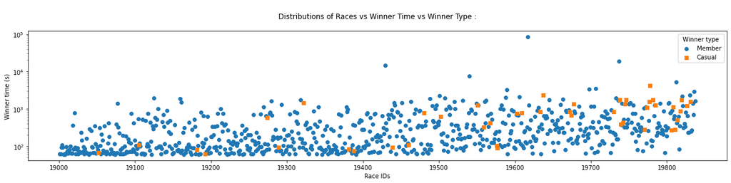

```python
# plotting races vs winner times vs winner type

plt.figure(figsize = [21, 4])
for cat, marker in cat_markers :
    df_cat = capital_race.query('winner_type == "{}"'.format(cat))
    plt.scatter(data = df_cat, x = 'race_id', y = 'winner_time', marker = marker)
plt.xticks([19000, 19100, 19200, 19300, 19400, 19500, 19600, 19700, 19800])
plt.xlabel('Race IDs')
plt.ylabel('Winner time (s)')
plt.yscale('log')
plt.legend(['Member', 'Casual'], title = 'Winner type')
plt.title('\nDistributions of Races vs Winner Time vs Winner Type :\n');
```

The logarithmic scale for *winner_time* variable show us its linear distribution with *race_id* variable. We can see Member biker type along this line but Casual biker type show up as line progress.

**What is the relatioship between races, participants and winners types ?**

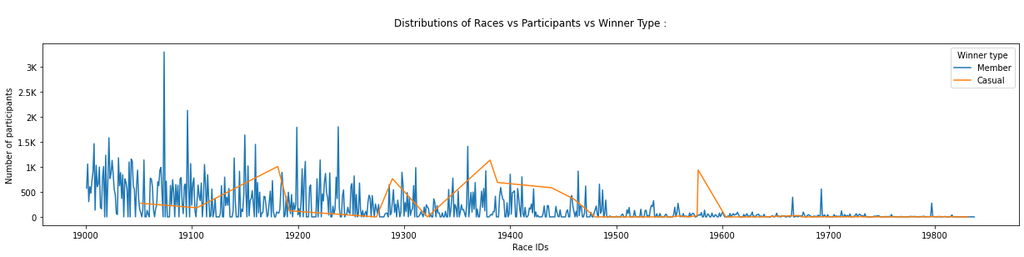

```python
# plotting races vs participants vs biker types

plt.figure(figsize = [21, 4])
for cat, marker in cat_markers :
    cat_df = capital_race.query('winner_type == "{}"'.format(cat))
    plt.errorbar(data = cat_df, x = 'race_id', y = 'participants')
plt.xticks([19000, 19100, 19200, 19300, 19400, 19500, 19600, 19700, 19800])
plt.yticks([0, 500, 1e3, 1.5e3, 2e3, 2.5e3, 3e3], [0, 500, '1K', '1.5K', '2K', '2.5K', '3K'])
plt.xlabel('Race IDs')
plt.ylabel('Number of participants')
plt.legend(['Member', 'Casual'], title = 'Winner type')
plt.title('\nDistributions of Races vs Participants vs Winner Type :\n');
```

There are the lines of *race_id* and *participants* variables. We can see in this distribution that each biker type decrease as the races follow each another.

### Talk about some of the relationships you observed in this part of the investigation. Were there features that strengthened each other in terms of looking at your feature(s) of interest ?

I extended my investigation of races against time in this section, by looking at the impact of the biker type and the number of participants. At the beginning, we observed that the number of participants decreased as the races followed each other, but the time taken by the winner was unpredictable. Then, we found that the winners were mainly the Member bike type the majority. And eventually, minority Casual bike type winners began to emerge as the number of participants decreased.

## Conclusions

To conclude, the performance (best time) are decisive in predicting which will be the best bike, but there is also that of the number of races and that of the number of participants in a race. Thus, the Member bike type majority has the best chance of winning the tournament.